# Исследование сервиса аренды самокатов

Рынок проката самокатов стремительно растет, поэтому понимание его особенностей и потребностей пользователей - ключевой фактор успеха любого сервиса. Это исследование позволит получить глубокое представление о рынке, идентифицировать ключевые факторы успеха и спланировать стратегию развития бизнеса.

Имеются данные о некоторых пользователях из нескольких городов, а также об их поездках. Необходимо проанализировать данные и проверить некоторые гипотезы, которые могут помочь бизнесу вырасти.

# Описание данных

**Пользователи — `users_go.csv`**

- `user_id` - уникальный идентификатор пользователя
- `name` - имя пользователя
- `age` - возраст
- `city` - город
- `subscription_type` - тип подписки (free, ultra)

**Поездки — `rides_go.csv`**

- `user_id` - уникальный идентификатор пользователя
- `distance` - расстояние, которое пользователь проехал в текущей сессии (в метрах)
- `duration` - продолжительность сессии (в минутах) — время с того момента, как пользователь нажал кнопку «Начать поездку» до момента, как он нажал кнопку «Завершить поездку»
- `date` - дата совершения поездки

**Подписки — `subscriptions_go.csv`**

- `subscription_type` - тип подписки
- `minute_price` - стоимость одной минуты поездки по данной подписке
- `start_ride_price` - стоимость начала поездки
- `subscription_fee` - стоимость ежемесячного платежа

# План работы

**Шаг 1. Загрузка данных**

1. СчитайтЬ CSV-файлы с данными с помощью библиотеки pandas и сохранить их в датафреймы. Пути к файлам:

`/datasets/users_go.csv`

`/datasets/rides_go.csv`

`/datasets/subscriptions_go.csv`

1. Вывести первые строки каждого набора данных. Изучить общую информацию о каждом датафрейме.

**Шаг 2. Предобработка данных**

1. Привести столбец `date` к типу даты pandas.
2. Создать новый столбец с номером месяца на основе столбца `date`.
3. Проверить наличие пропущенных значений и дубликатов в датафреймах. Обработать их, если такие значения присутствуют.

**Шаг 3. Исследовательский анализ данных**

Описать и визуализировать общую информацию о пользователях и поездках:

- частота встречаемости городов;
- соотношение пользователей с подпиской и без подписки;
- возраст пользователей;
- расстояние, которое пользователь преодолел за одну поездку;
- продолжительность поездок.

**Шаг 4. Объединение данных**

1. Объединить данные о пользователях, поездках и подписках в один датафрейм. Для этого воспользуемся методом merge().
2. Создать ещё два датафрейма из датафрейма, созданного на этапе 4.1:
- c данными о пользователях без подписки;
- с данными о пользователях с подпиской.
1. Визуализировать информацию о расстоянии и времени поездок для пользователей обеих категорий.

**Шаг 5. Подсчёт выручки**

1. Создать датафрейм с агрегированными данными о поездках на основе датафрейма с объединёнными данными из шага 4.
2. В этот же датафрейм добавить столбец с помесячной выручкой, которую принёс каждый пользователь. Для этого обратимся к информации об условиях оплаты для подписчиков и тех, у кого нет подписки. Продолжительность каждой поездки в каждой строке исходного датафрейма для подсчёта стоимости округляется до следующего целого числа.

**Шаг 6. Проверка гипотез**

Продакт-менеджеры сервиса хотят увеличить количество пользователей с подпиской. Для этого они будут проводить различные акции, но сначала нужно выяснить несколько важных моментов.

1. Важно понять, тратят ли пользователи с подпиской больше времени на поездки? Если да, то пользователи с подпиской могут быть «выгоднее» для компании.
2. Расстояние одной поездки в 3130 метров — оптимальное с точки зрения износа самоката. Можно ли сказать, что среднее расстояние, которое проезжают пользователи с подпиской за одну поездку, не превышает 3130 метров? Проверить гипотезу и сделать выводы.
3. Проверить гипотезу о том, будет ли помесячная выручка от пользователей с подпиской по месяцам выше, чем выручка от пользователей без подписки. Сделать вывод.
4. Представить такую ситуацию: техническая команда сервиса обновила сервера, с которыми взаимодействует мобильное приложение. Она надеется, что из-за этого количество обращений в техподдержку значимо снизилось. Некоторый файл содержит для каждого пользователя данные о количестве обращений до обновления и после него. Какой тест понадобился бы для проверки этой гипотезы?

**Шаг 7. Распределения**

1. Отделу маркетинга GoFast поставили задачу: нужно провести акцию с раздачей промокодов на один бесплатный месяц подписки, в рамках которой как минимум 100 существующих клиентов должны продлить эту подписку. То есть по завершении периода действия подписки пользователь может либо отказаться от неё, либо продлить, совершив соответствующий платёж. Эта акция уже проводилась ранее и по итогу выяснилось, что после бесплатного пробного периода подписку продлевают 10 % пользователей. Выяснить, какое минимальное количество промокодов нужно разослать, чтобы вероятность не выполнить план была примерно 5 %. Подобрать параметры распределения, описывающего эту ситуацию, построить график распределения и сформулировать ответ на вопрос о количестве промокодов.
2. Отдел маркетинга рассылает клиентам push-уведомления в мобильном приложении. Клиенты могут открыть его или не открывать. Известно, что уведомления открывают около 40 % получивших клиентов. Отдел планирует разослать 1 млн уведомлений. С помощью аппроксимации построить примерный график распределения и оценить вероятность того, что уведомление откроют не более 399,5 тыс. пользователей.

```python
import pandas as pd
import numpy as np
import matplotlib.pyplot as plt
from scipy import stats as st
from scipy.stats import binom, poisson
from math import sqrt
from math import factorial
```

#### Шаг 1. Загрузка данных

```python
try:
    data_users = pd.read_csv('users_go.csv')
    data_rides = pd.read_csv('rides_go.csv')
    data_subscriptions = pd.read_csv('subscriptions_go.csv')
except:
    data_users = pd.read_csv('https://code.s3.yandex.net/datasets/users_go.csv')
    data_rides = pd.read_csv('https://code.s3.yandex.net/datasets/rides_go.csv')
    data_subscriptions = pd.read_csv('https://code.s3.yandex.net/datasets/subscriptions_go.csv')
```

```python
data_users.head(10)
```

|  | user_id | name | age | city | subscription_type |
| --- | --- | --- | --- | --- | --- |
| 0 | 1 | Кира | 22 | Тюмень | ultra |
| 1 | 2 | Станислав | 31 | Омск | ultra |
| 2 | 3 | Алексей | 20 | Москва | ultra |
| 3 | 4 | Константин | 26 | Ростов-на-Дону | ultra |
| 4 | 5 | Адель | 28 | Омск | ultra |
| 5 | 6 | Регина | 25 | Краснодар | ultra |
| 6 | 7 | Игорь | 23 | Омск | ultra |
| 7 | 8 | Юрий | 23 | Краснодар | ultra |
| 8 | 9 | Ян | 21 | Пятигорск | ultra |
| 9 | 10 | Валерий | 18 | Екатеринбург | ultra |

```python
data_users.info()
```

```
<class 'pandas.core.frame.DataFrame'>
RangeIndex: 1565 entries, 0 to 1564
Data columns (total 5 columns):
 #   Column             Non-Null Count  Dtype
---  ------             --------------  -----
 0   user_id            1565 non-null   int64
 1   name               1565 non-null   object
 2   age                1565 non-null   int64
 3   city               1565 non-null   object
 4   subscription_type  1565 non-null   object
dtypes: int64(2), object(3)
memory usage: 61.3+ KB
```

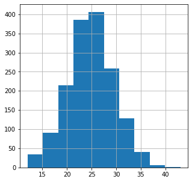

```python
data_users['age'].hist(figsize=(5,5));
```

```python
data_rides.head(10)
```

|  | user_id | distance | duration | date |
| --- | --- | --- | --- | --- |
| 0 | 1 | 4409.919140 | 25.599769 | 2021-01-01 |
| 1 | 1 | 2617.592153 | 15.816871 | 2021-01-18 |
| 2 | 1 | 754.159807 | 6.232113 | 2021-04-20 |
| 3 | 1 | 2694.783254 | 18.511000 | 2021-08-11 |
| 4 | 1 | 4028.687306 | 26.265803 | 2021-08-28 |
| 5 | 1 | 2770.890808 | 16.650138 | 2021-10-09 |
| 6 | 1 | 3039.020292 | 14.927879 | 2021-10-19 |
| 7 | 1 | 2842.118050 | 23.117468 | 2021-11-06 |
| 8 | 1 | 3412.690668 | 15.238072 | 2021-11-14 |
| 9 | 1 | 748.690645 | 15.041884 | 2021-11-22 |

```python
data_rides.info()
```

```
<class 'pandas.core.frame.DataFrame'>
RangeIndex: 18068 entries, 0 to 18067
Data columns (total 4 columns):
 #   Column    Non-Null Count  Dtype
---  ------    --------------  -----
 0   user_id   18068 non-null  int64
 1   distance  18068 non-null  float64
 2   duration  18068 non-null  float64
 3   date      18068 non-null  object
dtypes: float64(2), int64(1), object(1)
memory usage: 564.8+ KB
```

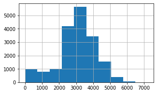

```python
data_rides['distance'].hist(figsize=(5,3));
```

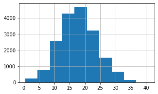

```python
data_rides['duration'].hist(figsize=(5,3));
```

```python
data_subscriptions.head(5)
```

|  | subscription_type | minute_price | start_ride_price | subscription_fee |
| --- | --- | --- | --- | --- |
| 0 | free | 8 | 50 | 0 |
| 1 | ultra | 6 | 0 | 199 |

```python
data_subscriptions.info()
```

```
<class 'pandas.core.frame.DataFrame'>
RangeIndex: 2 entries, 0 to 1
Data columns (total 4 columns):
 #   Column             Non-Null Count  Dtype
---  ------             --------------  -----
 0   subscription_type  2 non-null      object
 1   minute_price       2 non-null      int64
 2   start_ride_price   2 non-null      int64
 3   subscription_fee   2 non-null      int64
dtypes: int64(3), object(1)
memory usage: 192.0+ bytes
```

**Вывод:** по первичному просмотру данных, мы имеем:

- В датасете `data_users` 1565 строк и 5 колонок. Данные не имеют пропущенных значений, а также все столбцы имеют правильный тип данных. Наиболее часто встречаемый возраст пользователя - 25 лет.
- В датасете `data_rides` 18068 строк и 4 колонки. Данные не имеют пропущенных значений. В данных не все столбцы имеют правильный тип данных (`date`). Наиболее часто встречаемая дистанция, которое пользователь проехал в текущей сессии - 3500 м. Наиболее часто встречаемая продолжительность сессии - 18 минут.
- В датасете `subscriptions` 2 строки и 4 колонки. Данные не имеют пропущенных значений, а также все столбцы имеют правильный тип данных.

#### Шаг 2. Предобработка данных

```python
#Приведем столбец `date` в датасете `data_rides` к правильному типу "datetime64"
data_rides['date'] = pd.to_datetime(data_rides['date'], format = '%Y-%m-%d')
```

```python
#Создим новый столбец с номером месяца на основе столбца `date`
data_rides['month'] = data_rides['date'].dt.month
```

```python
#Проверим наличие дубликатов в датасете `data_users`
data_users.duplicated().sum()
```

```
31
```

```python
#Проверим наличие дубликатов в датасете `data_rides`
data_rides.duplicated().sum()
```

```
0
```

```python
#Избавимся от дубликатов в датасете `data_users`
data_users.drop_duplicates(inplace=True)
data_users.duplicated().sum()
```

```
0
```

```python
# Проверим за какой период у нас данные
data_rides['date'].dt.year.unique()
```

```
array([2021], dtype=int64)
```

```python
print('Максимальная продолжительность поездки:', data_rides['duration'].max().round(1), 'минут')
print('Минимальная продолжительность поездки:', data_rides['duration'].min(), 'минут')
```

```
Максимальная продолжительность поездки: 40.8 минут
Минимальная продолжительность поездки: 0.5 минут
```

**Вывод:** по итогам предобработки данных, был приведен столбец `date` в датасете `data_rides`с датой к правильному типу данных, добавлен в датасет `data_rides` столбец `month` с номером месяца по столбцу с датой. Проверены датасеты `data_users` и `data_rides` на дубликаты. Выявленные дубликаты были удалены. Проверен за какой период данные. Проверен столбец продолжительности поездок на предмет аномалии. Получилось 40.8 минут и 0.5 минут, как показывает практика, и такое время поездок бывает в реальной жизни.

#### Шаг 3. Исследовательский анализ данных

Опишем и визуализируем общую информацию о пользователях и поездках

```
Пятигорск         219
Екатеринбург      204
Ростов-на-Дону    198
Краснодар         193
Сочи              189
Омск              183
Тюмень            180
Москва            168
Name: city, dtype: int64
```

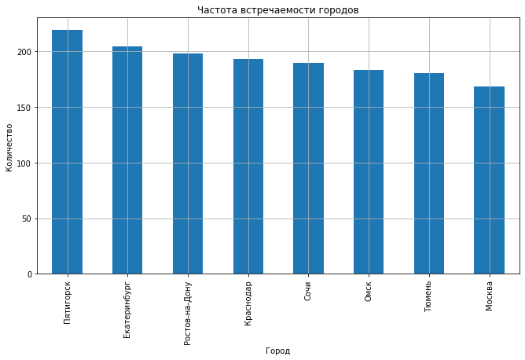

```python
#частота встречаемости городов
print(data_users['city'].value_counts())
data_users['city'].value_counts().plot(kind='bar', grid=True, title='Частота встречаемости городов', ylabel = 'Количество', xlabel = 'Город', figsize=(11,6));
```

**Вывод:** Наиболее часто встречаемый город аренды самокатов GoFast - Пятигорск (с частотой втсречаемости 219). Наименеее встречаемый - Москва (с частотой втсречаемости 168).

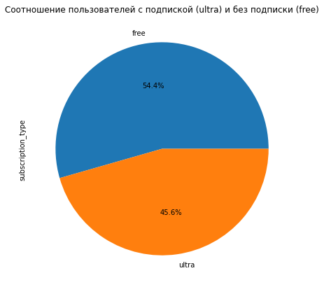

```python
# соотношение пользователей с подпиской и без подписки
data_users['subscription_type'].value_counts().plot(kind='pie', title = 'Соотношение пользователей с подпиской (ultra) и без подписки (free)', figsize=(7,7), autopct='%1.1f%%');
```

**Вывод:** В соотношении пользователей с подпиской и без подписки преобладают пользователи без подписки (в процентом соотношении 54,4%).

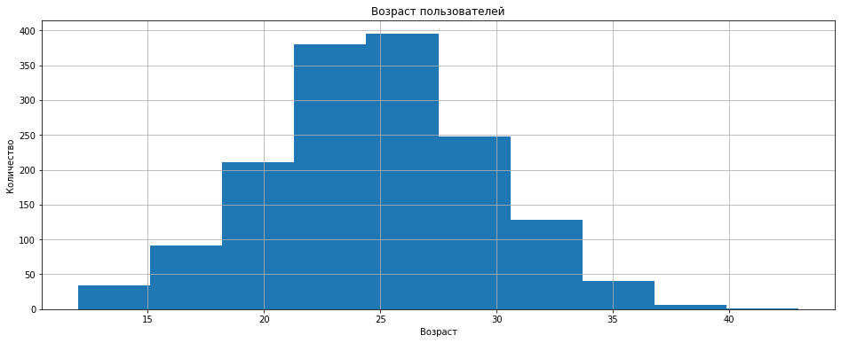

```python
#возраст пользователей
data_users['age'].plot(kind='hist', grid=True, title='Возраст пользователей', figsize=(16,6));
plt.xlabel('Возраст')
plt.ylabel('Количество')
plt.show()
```

**Вывод:** Наиболее часто встречаемый возраст пользователя совершавшего аренду самокатов GoFast - 25 лет. Наименеее встречаемый - 43 года.

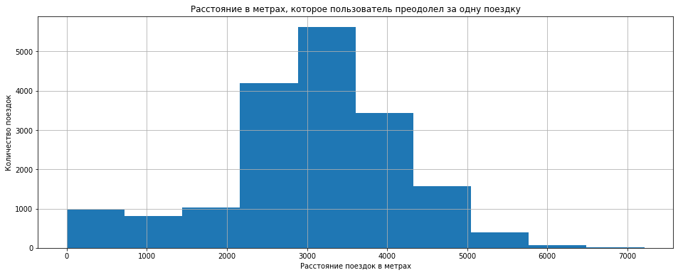

```python
#расстояние, которое пользователь преодолел за одну поездку
data_rides['distance'].plot(kind='hist', grid=True, title='Расстояние в метрах, которое пользователь преодолел за одну поездку', figsize=(16,6));
plt.xlabel('Расстояние поездок в метрах')
plt.ylabel('Количество поездок')
plt.show()
```

**Вывод:** Наиболее часто встречаемый диапазон расстояния, которое пользователь преодолел за одну поездку: 2.9-3.6 км. Реже всего проезжают расстояния свыше 5 км.

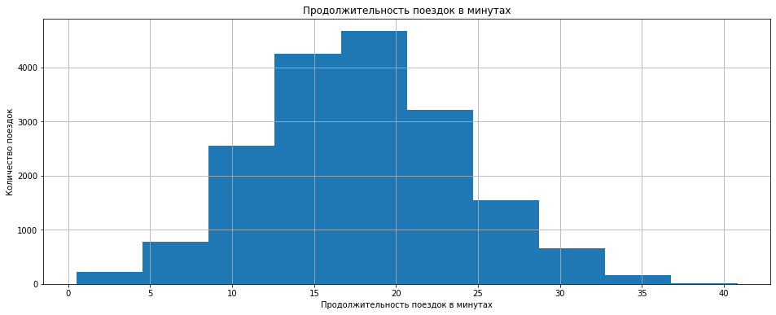

```python
#продолжительность поездок
data_rides['duration'].plot(kind='hist', grid=True, title='Продолжительность поездок в минутах', figsize=(16,6));
plt.xlabel('Продолжительность поездок в минутах')
plt.ylabel('Количество поездок')
plt.show()
```

**Вывод:** Наиболее часто встречаемый диапазон продолжительности поездок: 17-21 мин. Реже всего продолжительность поездки составляет менее 5 мин. и более 35 мин.

#### Шаг 4. Объединение данных

```python
#Объединим данные о пользователях, поездках и подписках в один датафрейм. Для этого воспользуемся методом merge().
data_users_rides = data_users.merge(data_rides, how='outer')
data = data_users_rides.merge(data_subscriptions, how='outer')
data.head(15)
```

|  | user_id | name | age | city | subscription_type | distance | duration | date | month | minute_price | start_ride_price | subscription_fee |
| --- | --- | --- | --- | --- | --- | --- | --- | --- | --- | --- | --- | --- |
| 0 | 1 | Кира | 22 | Тюмень | ultra | 4409.919140 | 25.599769 | 2021-01-01 | 1 | 6 | 0 | 199 |
| 1 | 1 | Кира | 22 | Тюмень | ultra | 2617.592153 | 15.816871 | 2021-01-18 | 1 | 6 | 0 | 199 |
| 2 | 1 | Кира | 22 | Тюмень | ultra | 754.159807 | 6.232113 | 2021-04-20 | 4 | 6 | 0 | 199 |
| 3 | 1 | Кира | 22 | Тюмень | ultra | 2694.783254 | 18.511000 | 2021-08-11 | 8 | 6 | 0 | 199 |
| 4 | 1 | Кира | 22 | Тюмень | ultra | 4028.687306 | 26.265803 | 2021-08-28 | 8 | 6 | 0 | 199 |
| 5 | 1 | Кира | 22 | Тюмень | ultra | 2770.890808 | 16.650138 | 2021-10-09 | 10 | 6 | 0 | 199 |
| 6 | 1 | Кира | 22 | Тюмень | ultra | 3039.020292 | 14.927879 | 2021-10-19 | 10 | 6 | 0 | 199 |
| 7 | 1 | Кира | 22 | Тюмень | ultra | 2842.118050 | 23.117468 | 2021-11-06 | 11 | 6 | 0 | 199 |
| 8 | 1 | Кира | 22 | Тюмень | ultra | 3412.690668 | 15.238072 | 2021-11-14 | 11 | 6 | 0 | 199 |
| 9 | 1 | Кира | 22 | Тюмень | ultra | 748.690645 | 15.041884 | 2021-11-22 | 11 | 6 | 0 | 199 |
| 10 | 1 | Кира | 22 | Тюмень | ultra | 4031.020195 | 17.674448 | 2021-12-14 | 12 | 6 | 0 | 199 |
| 11 | 1 | Кира | 22 | Тюмень | ultra | 2720.609748 | 9.529463 | 2021-12-22 | 12 | 6 | 0 | 199 |
| 12 | 2 | Станислав | 31 | Омск | ultra | 3105.086678 | 24.307514 | 2021-03-15 | 3 | 6 | 0 | 199 |
| 13 | 2 | Станислав | 31 | Омск | ultra | 3053.519401 | 11.543256 | 2021-03-18 | 3 | 6 | 0 | 199 |
| 14 | 2 | Станислав | 31 | Омск | ultra | 4029.116927 | 25.109188 | 2021-03-23 | 3 | 6 | 0 | 199 |

```python
# Проверим корректность объединения таблиц, для этого сравним размерность исходного датасета с объединенным, а также проверим на пропуски объединенный датасет
print('Размерность исходного датасета:', data_rides.shape)
print('Размерность объединенного датасета:', data.shape)
print('Количество пропусков в столбцах объединенного датасета:')
print(data.isna().sum())
```

```
Размерность исходного датасета: (18068, 5)
Размерность объединенного датасета: (18068, 12)
Количество пропусков в столбцах объединенного датасета:
user_id              0
name                 0
age                  0
city                 0
subscription_type    0
distance             0
duration             0
date                 0
month                0
minute_price         0
start_ride_price     0
subscription_fee     0
dtype: int64
```

```python
#Создим датафрейм c данными о пользователях без подписки
data_free = data[data['subscription_type'] == 'free']
data_free.head(5)
```

|  | user_id | name | age | city | subscription_type | distance | duration | date | month | minute_price | start_ride_price | subscription_fee |
| --- | --- | --- | --- | --- | --- | --- | --- | --- | --- | --- | --- | --- |
| 6500 | 700 | Айдар | 22 | Омск | free | 2515.690719 | 14.944286 | 2021-01-02 | 1 | 8 | 50 | 0 |
| 6501 | 700 | Айдар | 22 | Омск | free | 846.932642 | 16.234663 | 2021-02-01 | 2 | 8 | 50 | 0 |
| 6502 | 700 | Айдар | 22 | Омск | free | 4004.434142 | 20.016628 | 2021-02-04 | 2 | 8 | 50 | 0 |
| 6503 | 700 | Айдар | 22 | Омск | free | 1205.911290 | 9.782872 | 2021-02-10 | 2 | 8 | 50 | 0 |
| 6504 | 700 | Айдар | 22 | Омск | free | 3047.379435 | 17.427673 | 2021-02-14 | 2 | 8 | 50 | 0 |

```python
data_free.info()
```

```
<class 'pandas.core.frame.DataFrame'>
Int64Index: 11568 entries, 6500 to 18067
Data columns (total 12 columns):
 #   Column             Non-Null Count  Dtype
---  ------             --------------  -----
 0   user_id            11568 non-null  int64
 1   name               11568 non-null  object
 2   age                11568 non-null  int64
 3   city               11568 non-null  object
 4   subscription_type  11568 non-null  object
 5   distance           11568 non-null  float64
 6   duration           11568 non-null  float64
 7   date               11568 non-null  datetime64[ns]
 8   month              11568 non-null  int64
 9   minute_price       11568 non-null  int64
 10  start_ride_price   11568 non-null  int64
 11  subscription_fee   11568 non-null  int64
dtypes: datetime64[ns](1), float64(2), int64(6), object(3)
memory usage: 1.1+ MB
```

```python
#Создим датафрейм c данными о пользователях с подпиской
data_ultra = data[data['subscription_type'] == 'ultra']
data_ultra.tail(5)
```

|  | user_id | name | age | city | subscription_type | distance | duration | date | month | minute_price | start_ride_price | subscription_fee |
| --- | --- | --- | --- | --- | --- | --- | --- | --- | --- | --- | --- | --- |
| 6495 | 699 | Оксана | 22 | Москва | ultra | 3973.046497 | 24.671163 | 2021-08-29 | 8 | 6 | 0 | 199 |
| 6496 | 699 | Оксана | 22 | Москва | ultra | 3288.702563 | 15.892886 | 2021-09-12 | 9 | 6 | 0 | 199 |
| 6497 | 699 | Оксана | 22 | Москва | ultra | 3076.159348 | 14.389525 | 2021-09-26 | 9 | 6 | 0 | 199 |
| 6498 | 699 | Оксана | 22 | Москва | ultra | 4707.845501 | 15.839579 | 2021-10-17 | 10 | 6 | 0 | 199 |
| 6499 | 699 | Оксана | 22 | Москва | ultra | 3202.890770 | 25.217345 | 2021-12-03 | 12 | 6 | 0 | 199 |

```python
data_ultra.info()
```

```
<class 'pandas.core.frame.DataFrame'>
Int64Index: 6500 entries, 0 to 6499
Data columns (total 12 columns):
 #   Column             Non-Null Count  Dtype
---  ------             --------------  -----
 0   user_id            6500 non-null   int64
 1   name               6500 non-null   object
 2   age                6500 non-null   int64
 3   city               6500 non-null   object
 4   subscription_type  6500 non-null   object
 5   distance           6500 non-null   float64
 6   duration           6500 non-null   float64
 7   date               6500 non-null   datetime64[ns]
 8   month              6500 non-null   int64
 9   minute_price       6500 non-null   int64
 10  start_ride_price   6500 non-null   int64
 11  subscription_fee   6500 non-null   int64
dtypes: datetime64[ns](1), float64(2), int64(6), object(3)
memory usage: 660.2+ KB
```

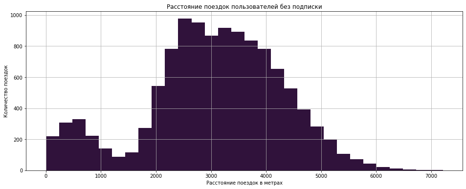

```python
# Визуализируем информацию о расстоянии поездок для пользователей без подписки
data_free['distance'].plot(kind='hist',  bins = 30, grid=True, colormap="turbo", figsize=(16,6));
plt.title('Расстояние поездок пользователей без подписки')
plt.xlabel('Расстояние поездок в метрах')
plt.ylabel('Количество поездок')
plt.show()
```

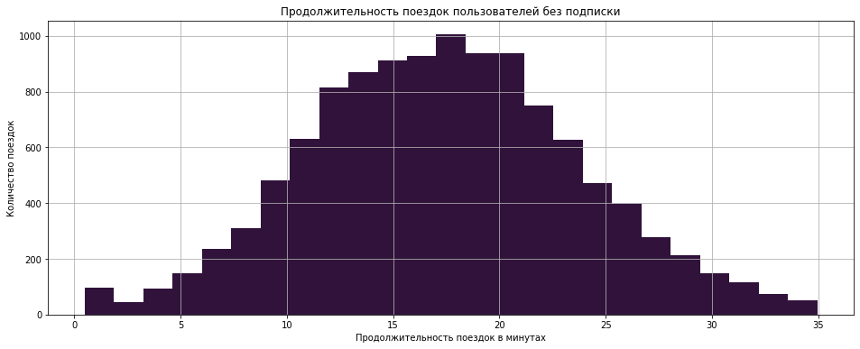

```python
# Визуализируем информацию о времени поездок для пользователей без подписки
data_free['duration'].plot(kind='hist', bins = 25, grid=True, colormap="turbo", figsize=(16,6));
plt.title('Продолжительность поездок пользователей без подписки')
plt.xlabel('Продолжительность поездок в минутах')
plt.ylabel('Количество поездок')
plt.show()
```

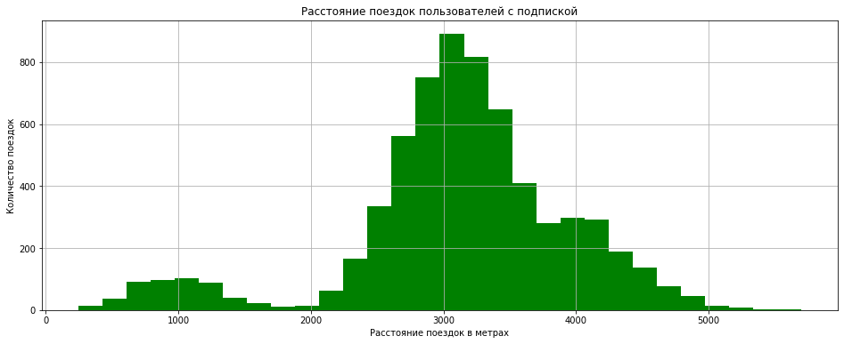

```python
# Визуализируем информацию о расстоянии поездок для пользователей с подпиской
data_ultra['distance'].plot(kind='hist',  bins = 30, grid=True, color="green", figsize=(16,6));
plt.title('Расстояние поездок пользователей с подпиской')
plt.xlabel('Расстояние поездок в метрах')
plt.ylabel('Количество поездок')
plt.show()
```

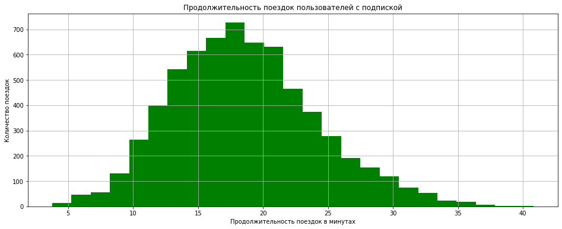

```python
# # Визуализируем информацию о времени поездок для пользователей с подпиской
data_ultra['duration'].plot(kind='hist', bins = 25, grid=True, color="green", figsize=(16,6));
plt.title('Продолжительность поездок пользователей с подпиской')
plt.xlabel('Продолжительность поездок в минутах')
plt.ylabel('Количество поездок')
plt.show()
```

**Вывод:** по получившимся датасетам c данными о пользователях без подписки и с подпиской, можно сказать:

- Пользователи без подписки преобладают над пользователями с подпиской;
- Наиболее частое количество поездок пользователей без подписки наблюдается с диапазоном расстояния поездки: 2.4-2.8 км. Также наблюдается активное количество поездок с расстоянием поездки до 1 км. Начиная с 6 км активность поездок минимальна.
- Наиболее частое количество поездок пользователей без подписки наблюдается с диапазоном продолжительности поездки: 17-18 минут. Меньше всего количество пользователей без подписки, совершавших поездку более 30 минут и менее 5 минут.
- Наиболее частое количество поездок пользователей с подпиской наблюдается с диапазоном расстояния поездки: 3.0-3.2 км. Также наблюдается наименее активное количество поездок с диапазонами расстояния поездки 1.8-2.0 км и более 5 км.
- Наиболее частое количество поездок пользователей с подпиской наблюдается с диапазоном продолжительности поездки: 17-18 минут. Меньше всего количество пользователей с подпиской, совершавших поездку более 35 минут и менее 5 минут.

#### Шаг 5. Подсчёт выручки

```python
# Найдем суммарное расстояние, количество поездок и суммарное время для каждого пользователя за каждый месяц
data_total = pd.pivot_table(data, index = ['user_id', 'month'], values = ['distance', 'duration', 'name', 'subscription_type'], aggfunc = {'distance': sum, 'duration': sum, 'name': len, 'subscription_type': max})
data_total.rename (columns = {'distance': 'sum_distance', 'duration': 'sum_duration', 'name': 'number_trips'}, inplace = True)
```

```python
data_total['sum_duration'] = np.ceil(data_total['sum_duration'])
```

```python
data_total.head(10)
```

| user_id | month | sum_distance | sum_duration | number_trips | subscription_type |
| --- | --- | --- | --- | --- | --- |
| 1 | 1 | 7027.511294 | 42.0 | 2 | ultra |
|  | 4 | 754.159807 | 7.0 | 1 | ultra |
|  | 8 | 6723.470560 | 45.0 | 2 | ultra |
|  | 10 | 5809.911100 | 32.0 | 2 | ultra |
|  | 11 | 7003.499363 | 54.0 | 3 | ultra |
|  | 12 | 6751.629942 | 28.0 | 2 | ultra |
| 2 | 3 | 10187.723006 | 61.0 | 3 | ultra |
|  | 4 | 6164.381824 | 40.0 | 2 | ultra |
|  | 6 | 3255.338202 | 14.0 | 1 | ultra |
|  | 7 | 6780.722964 | 47.0 | 2 | ultra |

```python
# Добавим столбец с помесячной выручкой, которую принёс каждый пользователь
# Помесячная выручка считается по формуле: стоимость старта поездки ×  количество поездок + стоимость одной минуты поездки × общая продолжительность всех поездок в минутах + стоимость подписки.

def revenue(row):
    if row['subscription_type'] == 'ultra':
        return row['sum_duration']*6+199
    elif row['subscription_type'] == 'free':
        return row['sum_duration']*8+50*row['number_trips']
```

```python
data_total['revenue'] = data_total.apply(revenue, axis = 1)
```

```python
data_total.head(10)
```

| user_id | month | sum_distance | sum_duration | number_trips | subscription_type | revenue |
| --- | --- | --- | --- | --- | --- | --- |
| 1 | 1 | 7027.511294 | 42.0 | 2 | ultra | 451.0 |
|  | 4 | 754.159807 | 7.0 | 1 | ultra | 241.0 |
|  | 8 | 6723.470560 | 45.0 | 2 | ultra | 469.0 |
|  | 10 | 5809.911100 | 32.0 | 2 | ultra | 391.0 |
|  | 11 | 7003.499363 | 54.0 | 3 | ultra | 523.0 |
|  | 12 | 6751.629942 | 28.0 | 2 | ultra | 367.0 |
| 2 | 3 | 10187.723006 | 61.0 | 3 | ultra | 565.0 |
|  | 4 | 6164.381824 | 40.0 | 2 | ultra | 439.0 |
|  | 6 | 3255.338202 | 14.0 | 1 | ultra | 283.0 |
|  | 7 | 6780.722964 | 47.0 | 2 | ultra | 481.0 |

```python
data_total.tail(10)
```

| user_id | month | sum_distance | sum_duration | number_trips | subscription_type | revenue |
| --- | --- | --- | --- | --- | --- | --- |
| 1533 | 8 | 4581.943632 | 22.0 | 1 | free | 226.0 |
|  | 11 | 3414.448028 | 26.0 | 1 | free | 258.0 |
| 1534 | 1 | 4678.415899 | 16.0 | 1 | free | 178.0 |
|  | 2 | 2103.914120 | 14.0 | 1 | free | 162.0 |
|  | 4 | 3434.290912 | 15.0 | 1 | free | 170.0 |
|  | 6 | 3409.468534 | 25.0 | 2 | free | 300.0 |
|  | 8 | 7622.453034 | 48.0 | 2 | free | 484.0 |
|  | 9 | 4928.173852 | 23.0 | 1 | free | 234.0 |
|  | 11 | 13350.015305 | 77.0 | 4 | free | 816.0 |
|  | 12 | 2371.711192 | 16.0 | 1 | free | 178.0 |

**Вывод:** по итогам 5-го шага было выполено следующее:

- Найдено суммарное расстояние, количество поездок и суммарное время для каждого пользователя за каждый месяц
- Добавили столбец с помесячной выручкой, которую принёс каждый пользователь.

#### Шаг 6. Проверка гипотез

*Задача №1*

Важно понять, тратят ли пользователи с подпиской больше времени на поездки? Если да, то пользователи с подпиской могут быть «выгоднее» для компании. Проверьте гипотезу. Используйте исходные данные о продолжительности каждой сессии — отдельно для подписчиков и тех, у кого нет подписки.

- За нулевую гипотезу Н0 примем: duration при ultra = duration при free
- За альтернативную гипотезу Н1 примем: duration при ultra > duration при free

```python
alpha = 0.05
results = st.ttest_ind(data_ultra['duration'], data_free['duration'], alternative = 'greater')
print('р-значение:', results.pvalue)

if results.pvalue < alpha:
    print('Отвергаем нулевую гипотезу')
else:
    print('Не получилось отвергнуть нулевую гипотезу')
```

```
р-значение: 1.2804098316645613e-34
Отвергаем нулевую гипотезу
```

*Задача №2*

Расстояние одной поездки в 3130 метров — оптимальное с точки зрения износа самоката. Можно ли сказать, что среднее расстояние, которое проезжают пользователи с подпиской за одну поездку, не превышает 3130 метров? Проверьте гипотезу и сделайте выводы.

- За нулевую гипотезу Н0 примем: distance при ultra = 3130
- За альтернативную гипотезу Н1 примем: distance при ultra > 3130

```python
alpha = 0.05
interested_value = 3130
results = st.ttest_1samp(data_ultra['distance'], interested_value, alternative = 'greater')
print('p-значение:', results.pvalue)

if results.pvalue < alpha:
    print('Отвергаем нулевую гипотезу')
else:
    print('Не получилось отвергнуть нулевую гипотезу')
```

```
p-значение: 0.9195368847849785
Не получилось отвергнуть нулевую гипотезу
```

*Задача №3*

Проверьте гипотезу о том, будет ли помесячная выручка от пользователей с подпиской по месяцам выше, чем выручка от пользователей без подписки. Сделайте вывод.

- За нулевую гипотезу Н0 примем: revenue при ultra = revenue при free
- За альтернативную гипотезу Н1 примем: revenue при ultra > revenue при free

```python
alpha = 0.05

revenue_ultra = data_total.loc[data_total['subscription_type']=='ultra', 'revenue']
revenue_free = data_total.loc[data_total['subscription_type']=='free', 'revenue']

results = st.ttest_ind(revenue_ultra, revenue_free, alternative = 'greater')
print('р-значение:', results.pvalue)

if results.pvalue < alpha:
    print('Отвергаем нулевую гипотезу')
else:
    print('Не удалось отвергнуть нулевую гипотезу')
```

```
р-значение: 2.8130926188487286e-35
Отвергаем нулевую гипотезу
```

По результам T-теста мы опровергли нулевую гипотезу, то есть, можно утверждать, что помесячная выручка от пользователей с подпиской по месяцам будет выше, чем выручка от пользователей без подписки.

*Задача №4*

Представьте такую ситуацию: техническая команда сервиса обновила сервера, с которыми взаимодействует мобильное приложение. Она надеется, что из-за этого количество обращений в техподдержку значимо снизилось. Некоторый файл содержит для каждого пользователя данные о количестве обращений до обновления и после него. Какой тест вам понадобился бы для проверки этой гипотезы?

В данной задаче речь идет об **односторонней** гипотезе о равенстве средних для зависимых (парных) выборок, то есть, понадобится метод scipy.stats.ttest_rel().

где μ1 и μ2 - средние значения до обновления и после него.

#### Шаг 7. Распределения

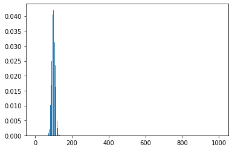

```python
p = 0.1
n = 1000

distr = []

for k in range(0, n + 1):
    choose = factorial(n) / (factorial(k) * factorial(n - k))
    prob = choose * p**k * (1-p)**(n-k)
    distr.append(prob)

plt.bar(range(0, n + 1), distr);
```

```python
n = 1000
p = 0.04

mu = n*p
sigma = sqrt(n*p*(1-p))

distr = st.norm(mu,sigma)

result = distr.cdf(30)
print(result)
```

```
0.0532915847874438
```

**2** Отдел маркетинга рассылает клиентам push-уведомления в мобильном приложении. Клиенты могут открыть его или не открывать. Известно, что уведомления открывают около 40 % получивших клиентов. Отдел планирует разослать 1 млн уведомлений. С помощью аппроксимации построить примерный график распределения и оценить вероятность того, что уведомление откроют не более 399,5 тыс. пользователей.

```python
n = 1000000
p = 0.4

mu = n * p
sigma = sqrt(n * p * (1 - p))

distr = st.norm(mu, sigma)

# считаем вероятность хвоста слева от 399,5 тысяч
result = distr.cdf(399500)
print(result)
```

```
0.15371708296369768
```

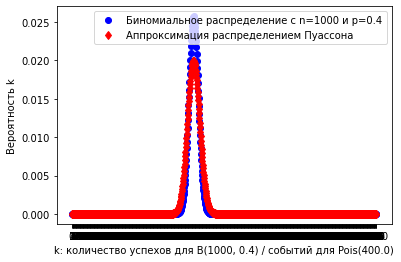

```python
n = 1000
p = 0.4

# считаем параметр распределения Пуассона для аппроксимации
lmbd = n * p

# задаем диапазон значений k для построения графика
max_value = 1000

binom_probs = []
poisson_probs = []
# для всех значений от 0 до 1000
for k in range(max_value + 1):
    # рассчитываем значения вероятности для биномиального распределения
    # и распределения Пуассона
    binom_prob = binom.pmf(k, n, p)
    poisson_prob = poisson.pmf(k, lmbd)
    # добавляем в соответствующие списки
    binom_probs.append(binom_prob)
    poisson_probs.append(poisson_prob)

# рисуем графики
plt.plot(range(max_value + 1), binom_probs, 'bo',
         label=f'Биномиальное распределение с n={n} и p={p}')
plt.plot(range(max_value + 1), poisson_probs, 'rd',
         label='Аппроксимация распределением Пуассона')
plt.xlabel(f'k: количество успехов для B{n, p} / событий для Pois({lmbd})')
plt.ylabel('Вероятность k')
plt.legend()
plt.xticks(range(max_value + 1))
plt.show()
```

*Ответ:* Вероятность того, что уведомление откроют не более 399,5 тыс. пользователей примерно равна 15%.

#### ОБЩИЙ ВЫВОД

**При изучении общей информации о каждом датафрейме, мы получили следуюшие данные:**

- В датасете `data_users` 1565 строк и 5 колонок. Данные не имеют пропущенных значений, а также все столбцы имеют правильный тип данных. Наиболее часто встречаемый возраст пользователя - 25 лет.
- В датасете `data_rides` 18068 строк и 4 колонки. Данные не имеют пропущенных значений. В данных не все столбцы имеют правильный тип данных (`date`). Наиболее часто встречаемая дистанция, которое пользователь проехал в текущей сессии - 3500 м. Наиболее часто встречаемая продолжительность сессии - 18 минут.
- В датасете `subscriptions` 2 строки и 4 колонки. Данные не имеют пропущенных значений, а также все столбцы имеют правильный тип данных.

**По итогам предобработки данных, мы добились следующих результатов:**

- был приведен столбец date в датасете data_ridesс датой к правильному типу данных;
- добавлен в датасет data_rides столбец month с номером месяца по столбцу с датой;
- проверены датасеты data_users и data_rides на дубликаты;
- выявленные дубликаты были удалены;
- проверен за какой период данные;
- проверен столбец продолжительности поездок на предмет аномалии. Получилось 40.8 минут и 0.5 минут, как показывает практика, и такое время поездок бывает в реальной жизни.

**В ходе исследовательского анализа данных было выявлено следующее:**

- Наиболее часто встречаемый город аренды самокатов GoFast - Пятигорск (с частотой втсречаемости 219). Наименеее встречаемый - Москва (с частотой втсречаемости 168);
- В соотношении пользователей с подпиской и без подписки преобладают пользователи без подписки (в процентом соотношении 54,4%);
- Наиболее часто встречаемый возраст пользователя совершавшего аренду самокатов GoFast - 25 лет. Наименеее встречаемый - 43 года;
- Наиболее часто встречаемый диапазон расстояния, которое пользователь преодолел за одну поездку: 2.9-3.6 км. Реже всего проезжают расстояния свыше 5 км.;
- Наиболее часто встречаемый диапазон продолжительности поездок: 17-21 мин. Реже всего продолжительность поездки составляет менее 5 мин. и более 35 мин.

**По получившимся датасетам c данными о пользователях без подписки и с подпиской, имеем следующую информацию:**

- Пользователи без подписки преобладают над пользователями с подпиской;
- Наиболее частое количество поездок пользователей без подписки наблюдается с диапазоном расстояния поездки: 2.4-2.8 км. Также наблюдается активное количество поездок с расстоянием поездки до 1 км. Начиная с 6 км активность поездок минимальна.
- Наиболее частое количество поездок пользователей без подписки наблюдается с диапазоном продолжительности поездки: 17-18 минут. Меньше всего количество пользователей без подписки, совершавших поездку более 30 минут и менее 5 минут.
- Наиболее частое количество поездок пользователей с подпиской наблюдается с диапазоном расстояния поездки: 3.0-3.2 км. Также наблюдается наименее активное количество поездок с диапазонами расстояния поездки 1.8-2.0 км и более 5 км.
- Наиболее частое количество поездок пользователей с подпиской наблюдается с диапазоном продолжительности поездки: 17-18 минут. Меньше всего количество пользователей с подпиской, совершавших поездку более 35 минут и менее 5 минут.

**Был произведен расчет выручки, в ходе которой были выполнены шаги:**

- Найдено суммарное расстояние, количество поездок и суммарное время для каждого пользователя за каждый месяц
- Добавлен столбец с помесячной выручкой, которую принёс каждый пользователь.

**При проверке гипотез, мы получили следующие результаты:**

Задача №3 - опровергли нулевую гипотезу, то есть, можно утверждать, что помесячная выручка от пользователей с подпиской по месяцам будет выше, чем выручка от пользователей без подписки.

Задача №4 - определена для проверки гипотеза о равенстве средних для зависимых (парных) выборок. И определен метод scipy.stats.ttest_rel().